# HW 2: Data Visualization & Analysis

#### - Ada Niu, Darshil Desai & Rashi Saxena

# Overview

Living in the city that is ranked as the second city in the United States, after New York, to have the best food, we felt that looking in the restaurant industry was very fitting. Our dataset is provided by Zomato. Zomato is a food delivery application founded in India in 2008. The application provides information and reviews about restaurants in 24 countries. Using this information, in this project we aim to explore this dataset sourced from [Kaggle](https://www.kaggle.com/shrutimehta/zomato-restaurants-data). Each row in this dataset has information of a restaurant around the world

Our goal in this project is to explore this dataset and evaluate following claims regarding the food industry:

- **(i)** Our analysis begins by trying to answer the question: do different parts of the world experience food differently? We establish and explore our claim for a selected number of popular cuisines served across the globe. These cuisines are as follows:
  - American
  - Mexican
  - Italian
  - Indian
- **(ii)** Next we will dive into some basic economics and explore the claim that, across the globe, restaurant price structures do not inherently represent food quality. We extend this analysis to different countries and regions (Asia, North America and so on)

  Many examples in our day to day life can represent how higher costs can reciprocate with more value. For example: higher costing cars are usually of a higher value with better engineering features. Higher costs of living in any given geography is usually indirectly or directly reciprocated with more economic opportunities and social utility.

  In this claim we seek to explore the possiblity of whether such a similar viewpoint is also directly or indirectly visible when considering the relationship between food quality and restaurant prices, measured by *aggregate ratings* and *Average cost for two* respectively. I.e: is there commonly visible causal relationship restaurant between prices and ratings across the globe? We pursue this analysis using a variety of data visualizaton techniques
- **(iii)** Finally we explore a smaller independent claim that focuses on how the extent to which technology is applied across big and small modernized cities in India. We ask the question: Is the increasing modernization of rich Indian cities reflected via tech savvy approaches in the restaurant industry? We apply this analysis by considering whether the frequency of restaurants allowing for online bookings and reservations

```python
# Importing required packages
import pandas as pd
import numpy as np
import matplotlib.pyplot as plt
import seaborn as sns

import os
import random
from sklearn.decomposition import PCA
from nltk.corpus import stopwords
from nltk.tokenize import sent_tokenize, word_tokenize

#setting the working dir
os.chdir('C:/Users/Darshil/Pacific/Semester 2/Data Viz/Assignments/HW2/UOP_DataVisualization_Analysis')

zom_df = pd.read_csv('zomato.csv')
```

# Data Wrangling & Preprocessing

The raw dataset requires some data processing in order for us to carry our any visual and statistical analysis. In general we will:

- **(i) Represent each country by name based on country code:** The raw dataset comprises of country codes uniqly identifying a given country. Although this data is sufficient to carry on any analysis pertaining to countries, representing each country by its name makes it relatively quicker to write code
- **(ii) Represent datapoints by its region:** The U.S. Department of Homeland Security breaks the world map into eight distinct geographic regions: Africa, Asia, the Caribbean, Central America, Europe, North America, Oceania and South America. Each of these regions contains a different mix of biomes and geographic features. We would also like to add represent our data on other geographic scales such as by region.

  This allows us to focus our geographic analysis not just by countries but also collectively by regions. For example: grouping the United States & Canada into one group - North America and so on
- **(iii) Standardize all currencies to USD:** The *Average Cost for two* feature value for any given datapoint is in the currency of the country the restaurant is in. We seek to standardize all non-US values to US values to draw conclusions and conduct anaysis on the same scale.

  For instance: Unstandardized restaurant costs in the US vs Indonesia will be incorrect if not normalized since $1USD = IRs. 13,970 therefore making it seem that restaurant prices in Indonesia are significantly higher
- **(iv) Remove Data with Missing Variables:** Before starting any analysis it is important to clean your data of any missing variables, because not doing so can significantly influence the conclusions that can be draw from the data

### (i) Represent each country by name based on country code

```python
#converting country codes to countries

conditions = [
    (zom_df['Country Code'] == 216),
    (zom_df['Country Code'] == 1),
    (zom_df['Country Code'] == 215),
    (zom_df['Country Code'] == 214),
    (zom_df['Country Code'] == 30),
    (zom_df['Country Code'] == 189),
    (zom_df['Country Code'] == 148),
    (zom_df['Country Code'] == 208),
    (zom_df['Country Code'] == 14),
    (zom_df['Country Code'] == 162),
    (zom_df['Country Code'] == 94),
    (zom_df['Country Code'] == 191),
    (zom_df['Country Code'] == 166),
    (zom_df['Country Code'] == 184),
    (zom_df['Country Code'] == 37)
]

choices = ['United States', 'India', 'UK', 'Dubai', 'Brazil', 'South Africa', 'New Zealand', 'Turkey',
          'Australia','Botswana', 'Indonesia', 'Sri Lanka', 'Qatar', 'Singapore', 'Canada']

zom_df['Country'] = np.select(conditions, choices, default='')
```

### (ii) Represent datapoints by region

```python
#converting country codes to regions

conditions = [
   (zom_df['Country Code'] == 216),
   (zom_df['Country Code'] == 1),
   (zom_df['Country Code'] == 215),
   (zom_df['Country Code'] == 214),
   (zom_df['Country Code'] == 30),
   (zom_df['Country Code'] == 189),
   (zom_df['Country Code'] == 148),
   (zom_df['Country Code'] == 208),
   (zom_df['Country Code'] == 14),
   (zom_df['Country Code'] == 162),
   (zom_df['Country Code'] == 94),
   (zom_df['Country Code'] == 191),
   (zom_df['Country Code'] == 166),
   (zom_df['Country Code'] == 184),
   (zom_df['Country Code'] == 37)
]

choices = ['North America', 'Asia','Europe','Asia','South America','Africa','Oceania','Asia','Oceania',
          'Africa','Asia','Asia','Asia','Asia','North America']

zom_df['Region'] = np.select(conditions, choices, default='')
```

### (iii) Standardize all currencies to USD

```python
# Standardize all currencies to USD

currency_val=  {
    'United States': 1,
    'India': 70,
    'UK': 0.76,
    'Dubai': 3.6,
    'Brazil': 3.651,
    'South Africa': 13,
    'New Zealand': 1.44,
    'Turkey': 5.19,
    'Australia': 1.3,
    'Botswana': 10.40,
    'Indonesia': 13948,
    'Sri Lanka': 178,
    'Qatar': 3.64,
    'Singapore': 1.35,
    'Canada': 1.32
}

#create empty dataframe
curr_df = pd.DataFrame( columns=['Country', 'Random'])
curr_df = curr_df.fillna('') # with 0s rather than NaNs


all_countries= list(currency_val.keys())
all_currency_ex = list(currency_val.values())

cc = all_countries
val = all_currency_ex

for x,y in zip(cc,val):

    #subset
    new_df1 = zom_df[zom_df['Country'] == x]
    new_df1 = new_df1[['Country', 'Average Cost for two', 'Region','Aggregate rating','Price range', 'Restaurant Name']]

    new_df1['Average Cost for two_USD'] = new_df1['Average Cost for two']/y

    #print (new_df.head(2))

    #     #append
    curr_df = pd.concat([curr_df,new_df1])

#check
#curr_df[curr_df['Country']=='India'].head()
```

### (iv) Remove Data with Missing Variables

```python
# removing missing var
zom_df = zom_df.dropna()
```

# Data Exploration

Our dataset, sourced from [Kaggle.com](https://www.kaggle.com/shrutimehta/zomato-restaurants-data), comprises of restaurant data from all over the world. Before we pursue explopring our dataset and highlighting significant insights of the same, we would like to provide brief explanations on our features:

- **Restaurant Id :** Unique id of every restaurant across various cities of the world
- **Restaurant Name :** Entire name of the restaurant
- **Country Code:** Unique code representing the country in which restaurant is located
- **City, Address, Locality, Locality Verbose:** General address attributes of the restaurant datapoint.
- **Longitude & Longitude:** Longitude & Longitude coordinates of the restaurant's location
- **Cuisines:** Cuisines offered by the restaurant. Important to understand that a restaurant can offer multiple cuisines- some of which may not be mutually exclusive. For instance: Italian & Pizza are seperated cuisines in many restaurants
- **Average Cost for two:** The mean cost of dining for 2 people in the given restaurant. We use this feature as a reference point for how expensive or cheap a restaurant is in US dollar terms.
- **Currency:** The currency in which the *Average Cost for two* metric is given in. For example: average cost of 2 for a data point in India may be 800 but in terms of Rupees.
- **Has Table booking:** Binary (yes/no) datapoint on whether the restaurant allows for reservations
- **Has Online delivery:** Binary (yes/no) datapoint on whether the restaurant delivers.
- **Is delivering:** Binary (yes/no) datapoint on whether the restaurant is currently delivering
- **Switch to order menu:** Binary (yes/no) datapoint on whether the restaurant allows ordering on the Zomato web app.
- **Price range:** This metric rages from 1 to 4 and gives a relative understanding of how pricey the food is relative to other restaurants in the city and the country
- **Aggregate Rating:** Average restauran rating out of 5. This is a continous variable that can hold any value between 0 and 5. For example: 4.5
- **Rating color & Rating Text:** Restaurant rating given in the form of color, text. The distribution is as follows:
  - White : Not rated
  - Red : Poor
  - Orange : Average
  - Yellow : Good
  - Green : Very Good
  - Dark Green : Excellent
- **Votes:** Number of ratings casted by people

### Viewing the dataset

```python
# Basic
zom_df.describe()
```

|  | Restaurant ID | Country Code | Longitude | Latitude | Average Cost for two | Price range | Aggregate rating | Votes |
| --- | --- | --- | --- | --- | --- | --- | --- | --- |
| count | 9.542000e+03 | 9542.000000 | 9542.000000 | 9542.000000 | 9542.000000 | 9542.000000 | 9542.000000 | 9542.000000 |
| mean | 9.043301e+06 | 18.179208 | 64.274997 | 25.848532 | 1200.326137 | 1.804968 | 2.665238 | 156.772060 |
| std | 8.791967e+06 | 56.451600 | 41.197602 | 11.010094 | 16128.743876 | 0.905563 | 1.516588 | 430.203324 |
| min | 5.300000e+01 | 1.000000 | -157.948486 | -41.330428 | 0.000000 | 1.000000 | 0.000000 | 0.000000 |
| 25% | 3.019312e+05 | 1.000000 | 77.081565 | 28.478658 | 250.000000 | 1.000000 | 2.500000 | 5.000000 |
| 50% | 6.002726e+06 | 1.000000 | 77.192031 | 28.570444 | 400.000000 | 2.000000 | 3.200000 | 31.000000 |
| 75% | 1.835260e+07 | 1.000000 | 77.282043 | 28.642711 | 700.000000 | 2.000000 | 3.700000 | 130.000000 |
| max | 1.850065e+07 | 216.000000 | 174.832089 | 55.976980 | 800000.000000 | 4.000000 | 4.900000 | 10934.000000 |

### Dataset Structure

```python
print ('Total number of datapoints in the give dataset: {}'.format(zom_df.shape[0]))
```

[output not shown]

```python
print ('Total number of features / variables in the give dataset: {}'.format(zom_df.shape[1]))
```

```
Total number of features / variables in the give dataset: 23
```

### Data Statistics

```python
zom_df.describe()
```

|  | Restaurant ID | Country Code | Longitude | Latitude | Average Cost for two | Price range | Aggregate rating | Votes |
| --- | --- | --- | --- | --- | --- | --- | --- | --- |
| count | 9.542000e+03 | 9542.000000 | 9542.000000 | 9542.000000 | 9542.000000 | 9542.000000 | 9542.000000 | 9542.000000 |
| mean | 9.043301e+06 | 18.179208 | 64.274997 | 25.848532 | 1200.326137 | 1.804968 | 2.665238 | 156.772060 |
| std | 8.791967e+06 | 56.451600 | 41.197602 | 11.010094 | 16128.743876 | 0.905563 | 1.516588 | 430.203324 |
| min | 5.300000e+01 | 1.000000 | -157.948486 | -41.330428 | 0.000000 | 1.000000 | 0.000000 | 0.000000 |
| 25% | 3.019312e+05 | 1.000000 | 77.081565 | 28.478658 | 250.000000 | 1.000000 | 2.500000 | 5.000000 |
| 50% | 6.002726e+06 | 1.000000 | 77.192031 | 28.570444 | 400.000000 | 2.000000 | 3.200000 | 31.000000 |
| 75% | 1.835260e+07 | 1.000000 | 77.282043 | 28.642711 | 700.000000 | 2.000000 | 3.700000 | 130.000000 |
| max | 1.850065e+07 | 216.000000 | 174.832089 | 55.976980 | 800000.000000 | 4.000000 | 4.900000 | 10934.000000 |

#### Total Number of Countries

```python
# Total number of countries
print ("The total number of countries in our dataset: {}".format(len(zom_df['Country'].unique())) )

print ('\nThey are as follows: ')
pd.Series(zom_df['Country'].unique())
```

```
The total number of countries in our dataset: 15

They are as follows:
```

```
0          Botswana
1            Brazil
2     United States
3         Australia
4            Canada
5         Singapore
6             Dubai
7             India
8         Indonesia
9       New Zealand
10               UK
11            Qatar
12     South Africa
13        Sri Lanka
14           Turkey
dtype: object
```

#### Total Number of Cities Around the World

```python
# Total number of cities
print ("The total number of cities in our dataset: {}".format(len(zom_df['City'].unique())) )
```

```
The total number of cities in our dataset: 140
```

#### Price Range of Average Cost for Two People

```python
# We use != 0 to remove a small insiginicant amount of datapoints where value for the average cost column is null

print('Average cost for 2 people in restaurants all over the world, based on our dataset, ranges from ${} cents to ${}'.format(
    round(curr_df[curr_df['Average Cost for two_USD']!=0]['Average Cost for two_USD'].min(),2),round(curr_df[curr_df['Average Cost for two_USD']!=0]['Average Cost for two_USD'].max()),2))
```

```
Average cost for 2 people in restaurants all over the world, based on our dataset, ranges from $0.71 cents to $577.0
```

### Cities with most reviews and corresponding ratings for their businesses

Do more votes == higher ratings?

```python
city_business_reviews = zom_df[['Country','City', 'Votes', 'Aggregate rating']].groupby(['Country','City']).\
agg({'Votes': 'sum', 'Aggregate rating': 'median'}).sort_values(by='Votes', ascending=False)
city_business_reviews.head(10)
```

| Country | City | Votes | Aggregate rating |
| --- | --- | --- | --- |
| India | New Delhi | 628340 | 3.10 |
|  | Gurgaon | 132160 | 3.20 |
|  | Noida | 73488 | 2.80 |
|  | Bangalore | 56115 | 4.40 |
|  | Kolkata | 44593 | 4.20 |
|  | Mumbai | 29697 | 4.00 |
|  | Chennai | 27695 | 4.30 |
| United States | Tampa Bay | 27407 | 4.45 |
| India | Hyderabad | 24135 | 4.25 |
| United States | Orlando | 22831 | 4.40 |

## Visualizing Important Insights

Here we will visualize some interesting observations we see in our dataset

### Ratings Distribution

We can observe that the Zomato Restaurants data focus geographically in India and the United States since major cities from these two countries have the highest amount of reviews. Statistically, we would prefer to use the mean when the sample size is large and does not include outliers. Since we are able to catch some outliers, which lie in the pool of "Poor" rating from the boxplot, use the median to describe the middle of a set of data that does have an outlier will be more desirable. So combining the table and the boxplot, we can draw conclusion that Cities have more votes aren't equivalent to have high ratings. For instance, New Delhi, serves as the capital of India, which has the most reviews, but the ratings is around average.

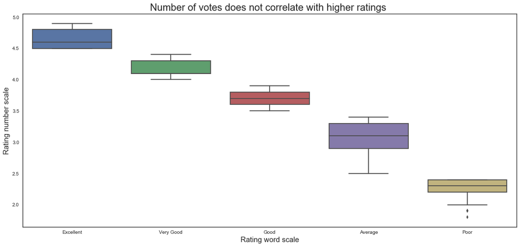

```python
# Detail information about rating "Average"
Average = zom_df[(zom_df['Rating text'] == 'Average') & (zom_df['Rating text'].str.contains('Not rated'))]['Aggregate rating']
Average.describe()

zom_df1 = zom_df[zom_df['Rating text'] != 'Not rated']
plt.figure(figsize=(18,8))
sns.boxplot(x = zom_df1['Rating text'], y = zom_df1['Aggregate rating'])
plt.xlabel('Rating word scale',fontsize = 15)
plt.ylabel('Rating number scale',fontsize = 15)
plt.title('Number of votes does not correlate with higher ratings ',fontsize = 20);
```

#### Number of Datapoints per country

Because this application was founded in India, one of our assumptions is that most of the observations are probably from India. To verify this, we would like to look at the number of restaurants per country in our dataset.

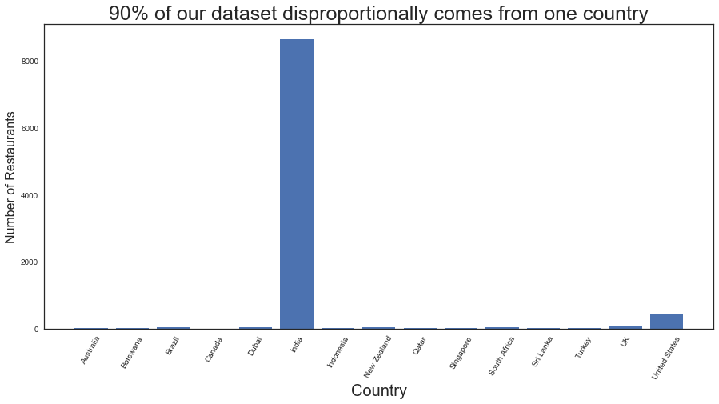

```python
plt.figure(figsize=(15,7))

rest_number = zom_df.groupby(['Country'], as_index=False).count()[['Country', 'Restaurant ID']]
rest_number.head()
rest_number.columns = ['Country', 'Number of Restaurants']

plt.bar(rest_number['Country'], rest_number['Number of Restaurants'])
plt.xlabel('Country', fontsize=20)
plt.rcParams['figure.figsize']=(30,20)
plt.ylabel('Number of Restaurants', fontsize=16)
plt.title('90% of our dataset disproportionally comes from one country', fontsize=25)
plt.xticks(rotation = 60) ;
```

```python
zomato_India = zom_df[zom_df['Country'] =='India'] #creating a subset of the dataset with only information about the restaurants in India
pd.DataFrame(round(zomato_India.count()/zom_df.count() * 100,2), columns =['Percentage of Restaurants in India']).head(2) #percentage of data from restaraunts in India
```

|  | Percentage of Restaurants in India |
| --- | --- |
| Restaurant ID | 90.67 |
| Restaurant Name | 90.67 |

#### Top 5 Most Expensive Restaurants by Region

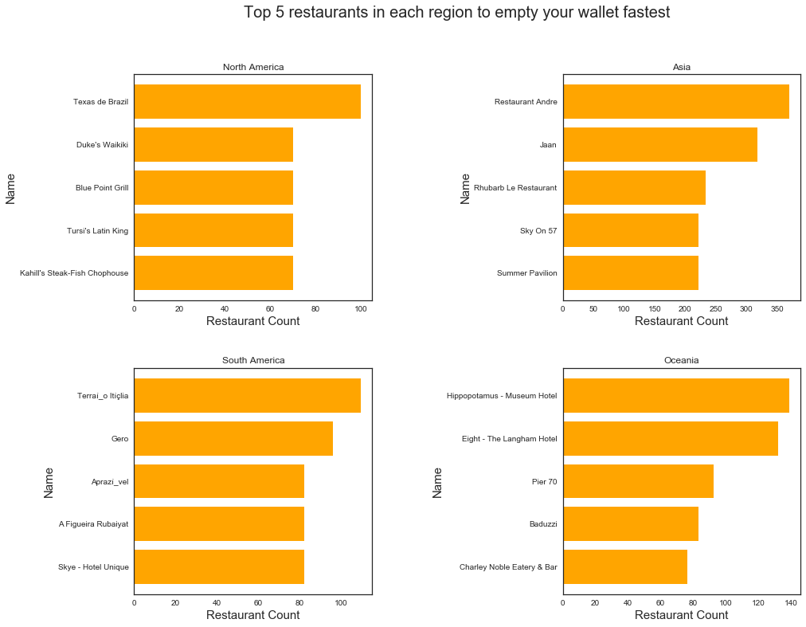

```python
plt.figure(figsize=(15,12))

plt.suptitle('Top 5 restaurants in each region to empty your wallet fastest', fontsize=20)

plt.subplots_adjust(left=None, bottom=None, right=None, top=None, wspace=0.8, hspace=0.3)

all_regions =['', 'North America', 'Asia' ,'South America', 'Oceania']

for i,r in zip(range(1,5),all_regions ):

    curr_df_country = curr_df[curr_df['Region']==all_regions[i]].sort_values('Average Cost for two_USD', ascending=True).tail(5)
    plt.subplot(2,2,i)
    plt.title('{}'.format(all_regions[i]))
    plt.barh(curr_df_country['Restaurant Name'],curr_df_country['Average Cost for two_USD'], color='orange' )
    plt.xlabel('Restaurant Count', fontsize=15)
    plt.ylabel('Name', fontsize=15) ;
```

#### Average cost per country box plot

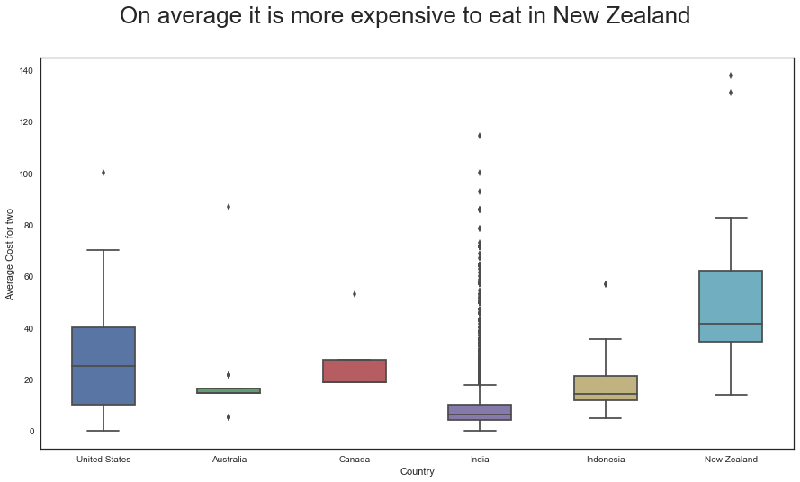

```python
df_ = pd.DataFrame( columns=['Country', 'Random'])
df_ = df_.fillna('a') # with 0s rather than NaNs


all_country_codes= list(zom_df['Country Code'].unique())
all_currency_ex = [100,3.7,1,1.38,1.32,1.35,3.67,70, 14074,1.45,0.76,3.64,13.48, 179.39, 5.24]

cc = all_country_codes
val = all_currency_ex

for x,y in zip(cc,val):

    #subset
    new_df = zom_df[zom_df['Country Code'] == x]
    new_df = new_df[['Country', 'Average Cost for two']]

    new_df['Average Cost for two'] = new_df['Average Cost for two']/y

    #print (new_df.head(2))

    #     #append
    df_ = pd.concat([df_,new_df])

tt = df_[df_['Country'].str.contains('United States|Australia|New Zealand|Canada|India|Indonesia')][['Country', 'Average Cost for two']]

plt.figure(figsize=(15,8))

plt.suptitle('On average it is more expensive to eat in New Zealand', fontsize=26)

sns.boxplot(y = tt['Average Cost for two'],
           x = tt['Country'], width = 0.5) ;
```

#### Distribution of top 10 cuisines globally

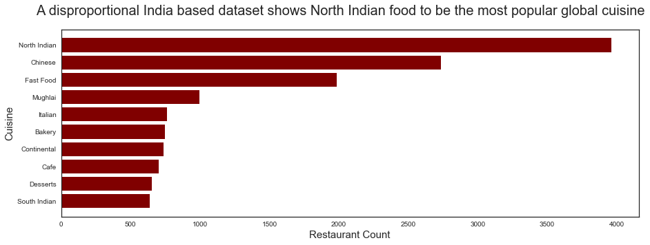

```python
plt.figure(figsize=(15,5))
plt.suptitle('A disproportional India based dataset shows North Indian food to be the most popular global cuisine', fontsize=20)

#-- code for unique value freq
zom_df2 = zom_df

zom_df2['Cuisines']  = zom_df['Cuisines'].astype(str)
aaa = zom_df2['Cuisines'].apply(lambda x: ' '.join([word for word in x.split()]) )

each_cuisine = [x for x in aaa]
emp = []

for x in each_cuisine:
    a = x.split(',')
    emp.extend(a)

emp  = [x.strip() for x in emp]
emp_s = pd.Series(emp)

emp_df = pd.DataFrame(emp_s.value_counts(dropna=False), columns=['count']).head(10).sort_values('count', ascending=True)


plt.barh(emp_df.index, emp_df['count'], color ='maroon')
plt.xlabel('Restaurant Count', fontsize=15)
plt.ylabel('Cuisine', fontsize=15) ;
```

#### Distribution of top 10 cuisines by Region

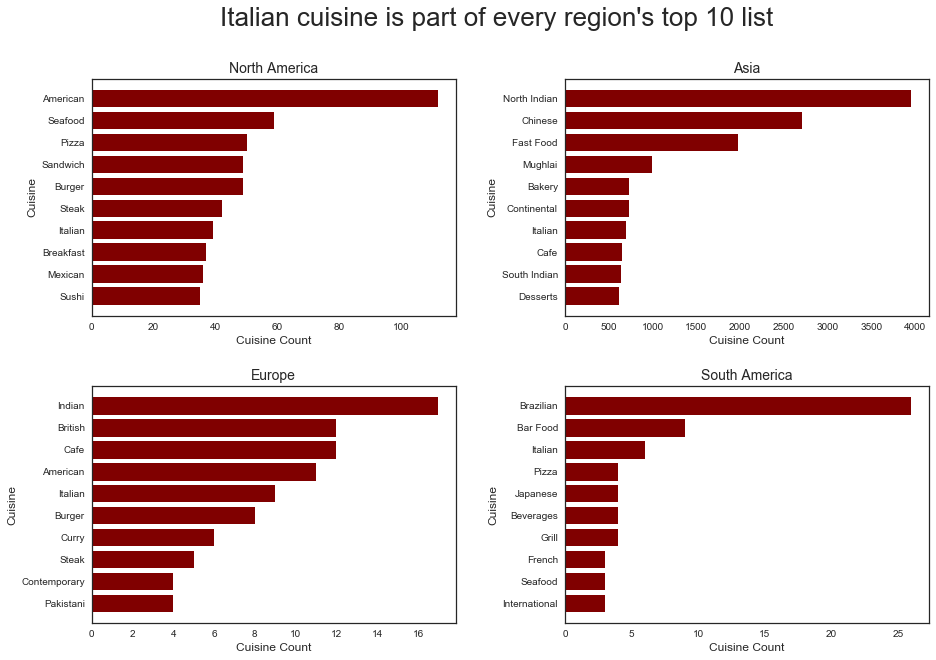

```python
plt.figure(figsize=(15,10))
plt.suptitle('Italian cuisine is part of every region\'s top 10 list', fontsize=26)
plt.subplots_adjust(left=None, bottom=None, right=None, top=None, wspace=0.3, hspace=0.3)


r_list = ['','North America', 'Asia', 'Europe', 'South America']
for i,x in zip(range(1,5) ,r_list):

    #-- code for unique value freq
    zom_df3 = zom_df[zom_df['Region']==r_list[i]]

    zom_df3['Cuisines']  = zom_df['Cuisines'].astype(str)
    aaa = zom_df3['Cuisines'].apply(lambda x: ' '.join([word for word in x.split()]) )

    each_cuisine = [x for x in aaa]
    emp = []

    for x in each_cuisine:
        a = x.split(',')
        emp.extend(a)

    emp  = [x.strip() for x in emp]
    emp_s = pd.Series(emp)

    emp_df = pd.DataFrame(emp_s.value_counts(dropna=False), columns=['count']).head(10).sort_values('count', ascending=True)


    plt.subplot(2,2,i)


    plt.barh(emp_df.index, emp_df['count'], color ='maroon')
    plt.title('{}'.format(r_list[i]), fontsize=14)
    plt.xlabel('Cuisine Count',fontsize = 12)
    plt.ylabel('Cuisine',fontsize = 12);
```

### Inter Correlations

In the correlation matrix below, we consider all the numerical variables except for **Restaurant_ID**, to observe whether there exist any relationships among them. The closer the value of a coefficient is to 1 or -1, the closer the relationship between the two data variables in question is. For example, the postive coefficient between **Aggregate_rating** and **Price_range** shows a moderate relationship in which rise in the value of one variable will show a corresponding rise in the value of the other variable

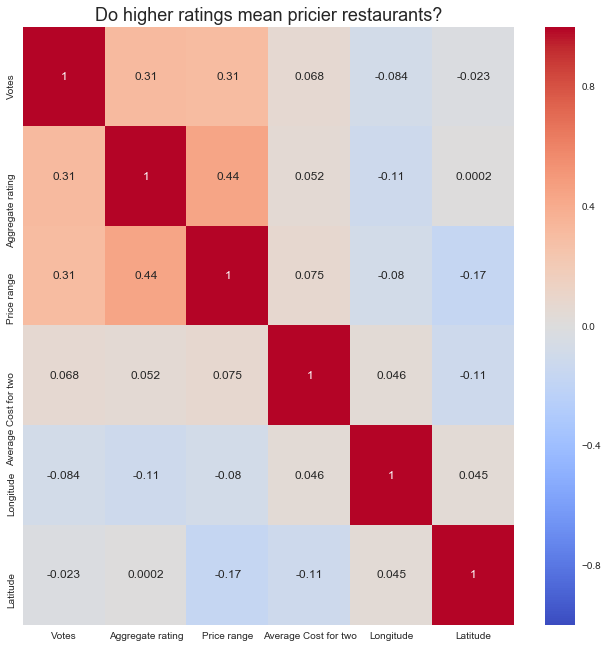

```python
corr = zom_df[['Votes','Aggregate rating','Price range','Average Cost for two','Longitude', 'Latitude']].corr()
fig, ax = plt.subplots(figsize=(11,11))
plt.title('Do higher ratings mean pricier restaurants?',fontsize = 18)
sns.heatmap(corr,annot=True,cmap='coolwarm',vmin=-1,vmax=1)
```

# Hypothesis & Analysis

### Claim 1: Different regions of the world experience food differently

We begin our analysis by first evaluating a claim that different regions of the world have different rating distributions for a specific number of cuisines. Through this analysis we explore how different cultures experience food differently. Using the *Aggregate rating* feature as a 'likability' we explore whether people around the globe like certain types of food in the same way or do some like it more than others? For instance, if the average ratings distribution of Mexican food is shaped similarily in North America & Oceania, we can conclude and support our claim in general countries in these two regions of the world like & experience Mexican food in a similar manner.

Specifically our claim here is that for any given cuisine there will be significant differences in their ratings distributions (and therefore differences in how much people like it in differenr parts of the world). Our selected cuisines to compare across the board are as follows:

- **Cuisine 1:** American
- **Cuisine 2:** Mexican
- **Cuisine 3:** Italian
- **Cuisine 4:** Indian

We explore the likability (*average ratings*) of these cuisines in the following regions: North America, South America, Asia, Africa, Europe & Oceania

### Violin Plots - Novel Tufte figure

We use violin plots to analyze the rating distributions from shape, center and spread. Using this method of visual analysis gives us insights about rating distributions for a selected number of cuisines from different regions of the world. We will see from the plots how rating distributions do vary in different regions for a certain cuisine. We can observe this variability through the spread of the ratings, density, and some skewness of the distributions.

In general terms, if the shape of the violin plot is more or less similar, i.e: the bulge on top or bottom half is the same for all countries for a given cuisine we can confirm refute our claim that a cusine is liked differently across the globe.

Lastly we would like to briefly explain how our Violinplots as our Novel Tufte figure meets the following requirements:

- Representation of numbers should match the true proportions.
- Labeling should be clear and detailed.
- Design should not vary for some ulterior motive, show only data variation

```
Text(0.5,1,'Indian')
```

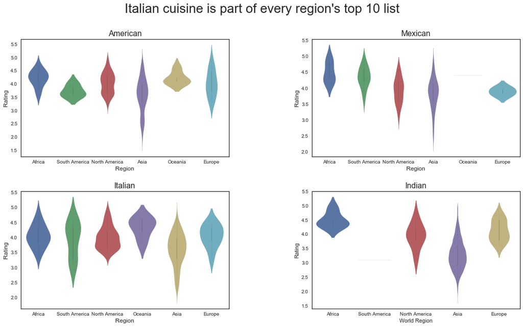

```python
plt.figure(figsize=(18,10))
plt.subplots_adjust(left=None, bottom=None, right=None, top=None, wspace=0.4, hspace=0.3)

plt.suptitle('Italian cuisine is part of every region\'s top 10 list', fontsize=26)

#-------------------------------------------
plt.subplot(2,2,1)

pizz = zom_df['Cuisines'].str.contains("American", case=False)
Res_df6 = zom_df[pizz]
Res_df6 = Res_df6[Res_df6['Aggregate rating'] != 0]

sns.violinplot(x=Res_df6.Region, y=Res_df6['Aggregate rating'], linewidth=0.1)
plt.xlabel('Region',fontsize = 12)
plt.ylabel('Rating',fontsize = 12)
plt.title('American',fontsize = 16)

#-------------------------------------------
plt.subplot(2,2,2)
Mexican = zom_df['Cuisines'].str.contains("Mexican|Brazilian", case=False)
Res_df4 = zom_df[Mexican]
Res_df4 = Res_df4[Res_df4['Aggregate rating'] != 0]


sns.violinplot(x=Res_df4.Region, y=Res_df4['Aggregate rating'], linewidth=0.1)
plt.xlabel('Region',fontsize = 12)
plt.ylabel('Rating',fontsize = 12)
plt.title('Mexican',fontsize = 16)
#-------------------------------------------
plt.subplot(2,2,3)
ity = zom_df['Cuisines'].str.contains("Italian|Pizza", case=False)
Res_df5 = zom_df[ity]
Res_df5 = Res_df5[Res_df5['Aggregate rating'] != 0]


sns.violinplot(x=Res_df5.Region, y=Res_df5['Aggregate rating'], linewidth=0.1)
plt.xlabel('Region',fontsize = 12)
plt.ylabel('Rating',fontsize = 12)
plt.title('Italian',fontsize = 16)
#-------------------------------------------
plt.subplot(2,2,4)
Indian = zom_df['Cuisines'].str.contains("Indian", case=False)
Res_df1 = zom_df[Indian]
Res_df1 = Res_df1[Res_df1['Aggregate rating'] != 0]


sns.violinplot(x=Res_df1.Region, y=Res_df1['Aggregate rating'], linewidth=0.1)
plt.xlabel('World Region')
plt.ylabel('Rating')
plt.title('Indian',fontsize = 16)
```

Based on the visual analysis above we observe the following:

**Conclusion:** We can conclude that our claim cannot be uphelp on account of a mutual and equivilent likabilty for Italian food across the globe. This phenomenon was not observed for different foods. For instance, Mexican cuisine in Asia has relatively wide spread while ratings in Europe generally concentrate between average and good. We also observe that particular type of cuisine being popular in certain region, as the graph shown, Indian food has above average ratings in Africa leading us to conclude that it is a cuisine favorited in this particular region.

## Claim 2: Exploring Correlations between Price & Ratings

In this section we move on to another independent claim that. In our exploratory analysis we observe a moderate relationship of 0.4 between the Price Range and Aggregate ratings. Using this metric one can inherently establish that there exists a proportional change in one variable given a change in the other. In this section we will exclusively look to refute this observation on a country by country and region by region basis. I.e: we claim that a restaurant's pricing structure is not correlational with its food quality, measured by ratings, across the globe.

As brielfy explained at the beggining of the our analysis, our motivation to evaluate this claim stems from the general viewpoint that in the current day and age higher costs are usually correlated with more reciprocated value. We beleive that this general viewpoint or observation, with regards to relationship between restaurant pricing and its food quality, does not hold at a global level.

We employ the use of visual analysis to pursue our claim:

- **(i) Measure Correlations**
- **(ii) Data Concentrations**

## (i.a) Correlation Analysis - Across Countries

Here we will employ the use of scatter plots to observe whether there exists any possible trends positive or negative correlation trends. We choose countries in different areas of the world and try and observe if there exist any causal or non-causal relationships.

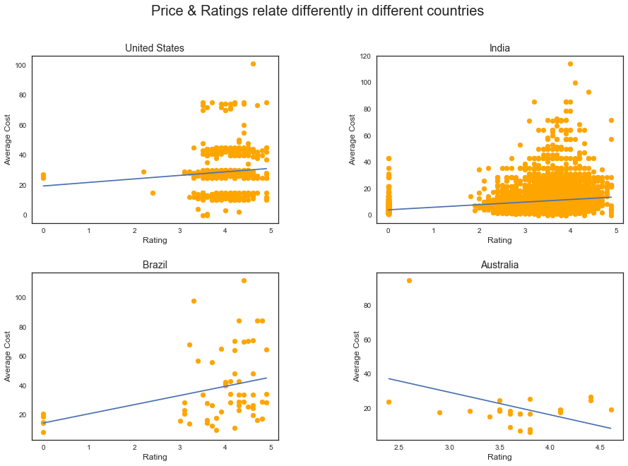

```python
plt.figure(figsize=(15,10))
plt.subplots_adjust(left=None, bottom=None, right=None, top=None, wspace=0.4, hspace=0.3)
plt.suptitle('Price & Ratings relate differently in different countries', fontsize=20)

for i,c,val in zip(range(1,5),[ 'United States','India', 'Brazil', 'Australia'], [1,70,3.6,1.3]):

    plt.subplot(2,2,i)
    plt.title('{}'.format(c) , fontsize=14)
    zz_country = zom_df[zom_df['Country']== c]
    plt.scatter(zz_country['Aggregate rating'],(zz_country['Average Cost for two'].apply(lambda x: x + random.randint(0,5))/val) ,c='orange')
    plt.plot(np.unique(zz_country['Aggregate rating']), np.poly1d(np.polyfit(zz_country['Aggregate rating'], zz_country['Average Cost for two'].apply(lambda x: x + random.randint(0,5))/val, 1))(np.unique(zz_country['Aggregate rating'])))
    plt.xlabel('Rating',fontsize = 12)
    plt.ylabel('Average Cost',fontsize = 12) ;
```

## (i.b) Correlation Analysis - Across Regions

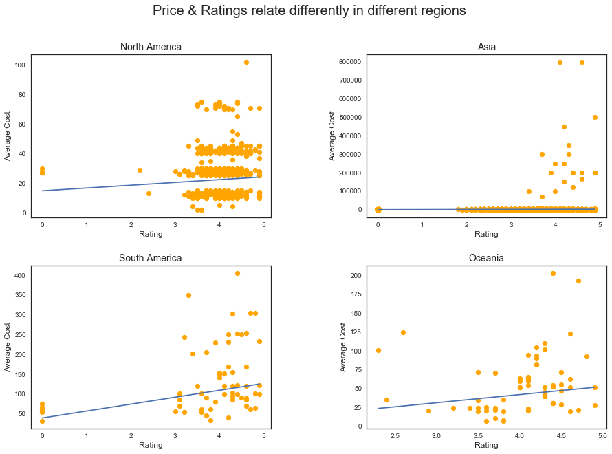

```python
plt.figure(figsize=(15,10))
plt.subplots_adjust(left=None, bottom=None, right=None, top=None, wspace=0.4, hspace=0.3)
plt.suptitle('Price & Ratings relate differently in different regions', fontsize=20)



for i,c in zip(range(1,5),[ 'North America','Asia', 'South America', 'Oceania']):

    plt.subplot(2,2,i)
    plt.title('{}'.format(c) , fontsize=14)
    zz_region = curr_df[curr_df['Region']== c]
    plt.scatter(zz_region['Aggregate rating'],(zz_region['Average Cost for two'].apply(lambda x: x + random.randint(0,5))/1) ,c='orange')
    plt.plot(np.unique(zz_region['Aggregate rating']), np.poly1d(np.polyfit(zz_region['Aggregate rating'], zz_region['Average Cost for two'].apply(lambda x: x + random.randint(0,5))/val, 1))(np.unique(zz_region['Aggregate rating'])))
    plt.xlabel('Rating',fontsize = 12)
    plt.ylabel('Average Cost',fontsize = 12) ;
```

From our visual analysis above we can observe the following:

- **United States:** In the US there exists a weak but clear correlation between ratings and prices. It is interesting to observe how restaurant pricing for those rated between 3-4 and largely distributed in the average US pricing region between \$20.0 - \\$50. However the distribution of restaurants between ratings 4 and 5 start to slowly trend in the higher pricing region. This phenomenon could convey perhaps that there exists a weak correlation that could perhaps be strengthened should there be a larger dataset for US restaurants.

  When considering the general trend of price vs ratings in the North America region, we observe how the United States follows it.
- **India:** The dataset disproprotionally contains restaurant data on India. Unlike in the United States we can see a weaker to non-existent correlation between ratings & pricing and a rather different distribution. For instance there exist more restaurants in the higher price range between \$50.0 and \\$100.0 rated between 3 and 4 than those rated 4 and above. Hence in the case of India there seems to be a very weak relationship between how food quality and pricing

  Unlike North America, Asia shows no promosing correlation at all. The difference between the North American & Asia price vs ratings correlations is the first refute to our claim.
- **Brazil:** Brazil's dataset paints a different picture as we can clearly see a stronger correlation between ratings and price. There exist more restaurants in the higher price range between \$50 & \\$60 rated 4 and above than those between 3 and 4 for instance. It is also interesting to note that this correlation will only strengthen as we add more datapoints pertaining to Brazil.

  Brazil follows the South American upward trending relationship between price and ratings.
- **Australia:** Australia's scatterplot, although showing a negative correlation, is skewed so by the outlier datapoint in the very high price range rated between 2.5 and 3. Removing this datapoint will show almost no correlation between ratings & prices in this part of the world.

**Conclusion:** In conclusion our visual anallysis **does not** support our claim being that the relationship between restaurant prices and its ratings is the same all over the world. We see that restaurant pricing models in Asian countries like India are unaffected by its ratings. Whereas on the other hand North and South American countries may have a truer relationship between prices and ratings such that for the most part, based on our visual analysis, we can say that pricier restaurants may have better tasting food. The differences between Australia and its parent geography entity Oceania also refutes our claim by showing that even within a region the relationships between price and ratings may tend to differ.

### (ii) Observing Concentrated Data

Briefly we will use a different set of visual tools to evaluate and analyze our claim from a different perspective. We employ the use of contour plots and determine if there exist any causal relationships by examining not only the concentration of data but also the general contour flow.

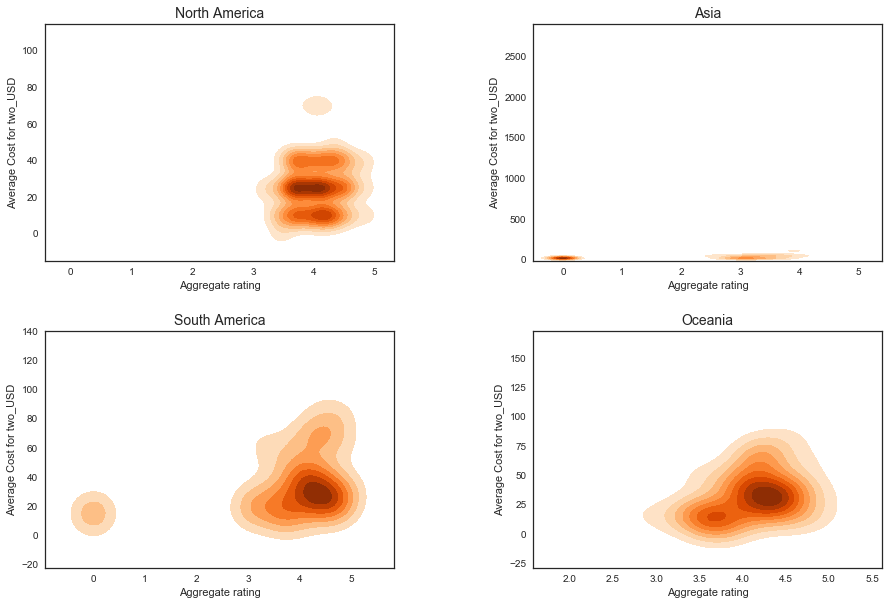

```python
plt.figure(figsize=(15,10))
plt.subplots_adjust(left=None, bottom=None, right=None, top=None, wspace=0.4, hspace=0.3)


for i,r in zip(range(1,5),[ 'North America', 'Asia','South America', 'Oceania']):

    plt.subplot(2,2,i)
    plt.title('{}'.format(r) , fontsize=14)
    zz_country = curr_df[curr_df['Region']== r]

    if i == 2:
        zz_country['Average Cost for two_USD'] = zz_country['Average Cost for two_USD']*5



    sns.kdeplot(zz_country['Aggregate rating'],zz_country['Average Cost for two_USD'],
                 cmap= 'Oranges', shade=True, shade_lowest=False)
```

Our analysis from the contour plots follow suit with the analysis from scatter plot and help us arrive at the conclusion that we **do not** have enough evidence to claim that everywhere in the world restaurant prices are unrelated to their ratings.

## Claim 3: Narrowing Focus on India

In our explanatory analysis we observed how over 90% of this dataset is based in India, given that the data is sourced from an India based web app. Therefore we deemed it appropriate to narrow our third and final claim to India, more specifically to New Delhi, Gurgaon, Noida, and Faridabad, because most of our data is from those regions. These regions can be characterized as being some of the most densely populated, modernized and expensive places in the country. Especially Delhi, it is the capital of India and the second most expensive city to live in within India.

Therefore in this section we explore a relatively uncomplicated claim that moderization in countries such as India is present and can be observed through the use of technology in the restaurant industry. We assume here that the priciest restaurants are most popular, explore where big city restaurants have ways to book a table online or through call ins as well as have online delivery systems in place

#### Number of Restaurants in Different Cities in India

From this graph below, we can confirm that a huge chunk of our data of restaraunts in India is provided from the city of New Delhi. New Delhi is a city in the northern region of India which justifies why North India is the most popular cuisine. The cities ranked after New Delhi are Gurgaon, Noida, and Faridabad. All three of these cities are neighboring cities of Delhi, and often have most people commuting from one city to another. Think of these cities being the Oakland, Foster City, and cities in South Bay to San Francisco.

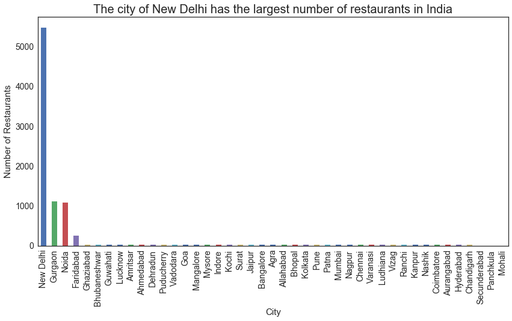

```python
restaurant_indiancity_number =zomato_India['City'].value_counts()
restaurant_indiancity_number.plot.bar(figsize=(14, 7),fontsize=14)
plt.title('The city of New Delhi has the largest number of restaurants in India', fontsize=20)
plt.xlabel('City', fontsize=15)
plt.ylabel('Number of Restaurants', fontsize=15) ;
```

```python
# Subset India data focusing on North Indian cities
north_india_zomato = zomato_India.loc[zomato_India.City.isin(['New Delhi','Gurgaon','Noida','Faridabad'])]
```

```
Text(0,0.5,'Number of Restaurants')
```

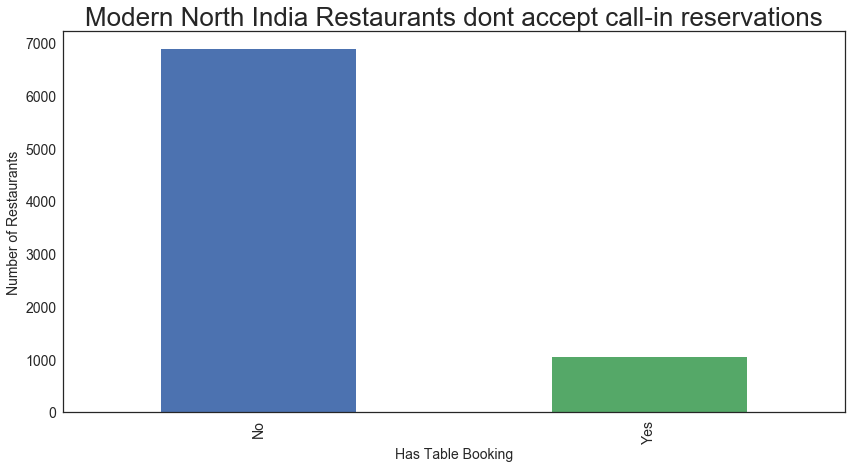

```python
plt.figure(figsize=(15,10))

table_booking  = north_india_zomato['Has Table booking'].value_counts()
table_booking.plot.bar(figsize=(14, 7),fontsize=14)
plt.title('Modern North India Restaurants dont accept call-in reservations', fontsize=26)
plt.xlabel('Has Table Booking', fontsize=14)
plt.ylabel('Number of Restaurants', fontsize=14)
```

```
Text(0,0.5,'Number of Restaurants')
```

[figure not shown]

```python
plt.figure(figsize=(15,10))

delivery  = north_india_zomato['Has Online delivery'].value_counts()
table_booking.plot.bar(figsize=(14, 7),fontsize=14)
plt.title('North Indian food in modernized Indian cities is still best received in-person', fontsize=20)
plt.xlabel('Online Delivery', fontsize=15)
plt.ylabel('Number of Restaurants', fontsize=15)
```